# FigureYa17 WGCNA_heatmap

Ying Ge; Yijing Chen

2025-5-20

## 需求描述

## requirement description

用R代码画出paper里WGCNA module的heatmap

Draw the heatmap of the WGCNA module in paper using R code

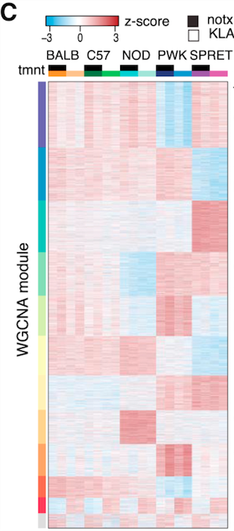

出自https://www.cell.com/cell/abstract/S0092-8674(18)30511-7

fromhttps://www.cell.com/cell/abstract/S0092-8674(18)30511-7

## 使用场景

## usage scenario

WGCNA找出了gene module，展示各module的基因在各组样本中的表达谱变化。

WGCNA identified gene modules to show the changes in the expression profiles of the genes of each module in each group of samples.

## 输入数据的预处理

## Preprocessing of input data

用FigureYa15WGCNA_module输出了各个gene module内的基因表达量，每个module保存在一个csv文件中，位于当前文件夹。

WGCNA已经按照共表达特征给基因分成了多个module，因此，这里不需要再做聚类，直接按照module内基因的数量给基因排序，再用热图的方式可视化。

如果你的数据已经保存成像`easy_input.csv`的格式，就可以跳过这步，直接进入“开始画图”。

Gene expression within each gene module was output using FigureYa15WGCNA_module, and each module was saved in a csv file located in the current folder.

WGCNA has already divided genes into modules according to co-expression characteristics, so there is no need to do clustering here, and genes are directly sorted according to the number of genes within a module, and then visualized by heatmap.

If your data has been saved in a format like `easy_input.csv`, you can skip this step and go directly to “Start drawing”.

```r
fnames<-Sys.glob("*.csv")
fnames
```

```
##  [1] "black.csv"     "blue.csv"      "brown.csv"     "cyan.csv"
##  [5] "green.csv"     "magenta.csv"   "pink.csv"      "purple.csv"
##  [9] "red.csv"       "salmon.csv"    "tan.csv"       "turquoise.csv"
```

读取这些module，合并。

Read these modules, merge them.

```r
fdataset<-lapply(fnames,read.csv)
names(fdataset) <- fnames

library(plyr)
result <- ldply(fdataset, data.frame)
head(result)
```

```
##         .id            X TPM_BALB_notx_rep1 TPM_BALB_notx_rep2
## 1 black.csv NM_001267808           2002.419           1906.353
## 2 black.csv    NM_007682           2244.010           1851.852
## 3 black.csv NM_001291894           1227.417           1174.517
## 4 black.csv    NM_011099            742.125            606.619
## 5 black.csv    NM_026381            621.223            709.701
## 6 black.csv    NM_008321            672.830            461.483
##   TPM_BALB_KLA_rep1 TPM_BALB_KLA_rep2 TPM_C57_notx_rep1 TPM_C57_notx_rep2
## 1          1684.282          1730.637          2448.148          2094.925
## 2          1587.257          1595.569          2038.935          1703.397
## 3          1660.177          1245.343          1043.985          1075.705
## 4           582.055           476.573           655.109           650.780
## 5           589.019           623.905           588.391           631.522
## 6           990.949           484.953           751.334           463.162
##   TPM_C57_KLA_rep1 TPM_C57_KLA_rep2 TPM_NOD_notx_rep1 TPM_NOD_notx_rep2
```

[output cut: 27 more lines]

```r
df<-result[,2:22]
df$module<-unlist(strsplit(result$.id,split = ".csv"))
head(df)
```

```
##              X TPM_BALB_notx_rep1 TPM_BALB_notx_rep2 TPM_BALB_KLA_rep1
## 1 NM_001267808           2002.419           1906.353          1684.282
## 2    NM_007682           2244.010           1851.852          1587.257
## 3 NM_001291894           1227.417           1174.517          1660.177
## 4    NM_011099            742.125            606.619           582.055
## 5    NM_026381            621.223            709.701           589.019
## 6    NM_008321            672.830            461.483           990.949
##   TPM_BALB_KLA_rep2 TPM_C57_notx_rep1 TPM_C57_notx_rep2 TPM_C57_KLA_rep1
## 1          1730.637          2448.148          2094.925         2401.025
## 2          1595.569          2038.935          1703.397         1731.283
## 3          1245.343          1043.985          1075.705         1309.804
## 4           476.573           655.109           650.780          563.337
## 5           623.905           588.391           631.522          549.526
## 6           484.953           751.334           463.162         1007.749
##   TPM_C57_KLA_rep2 TPM_NOD_notx_rep1 TPM_NOD_notx_rep2 TPM_NOD_KLA_rep1
```

[output cut: 27 more lines]

按照module内基因数量从多到少，给基因排序。

Order the genes according to the number of genes within the module from most to least.

```r
#先按module内基因的数量为module排序
#sort the module first by the number of genes in the module
module.num<-table(df$module)
module.num.sort<-module.num[order(module.num,decreasing =TRUE)]
module.num.sort
```

```
##
## turquoise      blue     brown     green       red     black      pink   magenta
##       454       433       340       283       230       226       201       166
##    purple       tan    salmon      cyan
##       156        58        40        38
```

```r
keys<-names(module.num.sort)
keysDF<-data.frame(module=keys,order=1:length(keys))
keysDF
```

```
##       module order
## 1  turquoise     1
## 2       blue     2
## 3      brown     3
## 4      green     4
## 5        red     5
## 6      black     6
## 7       pink     7
## 8    magenta     8
## 9     purple     9
## 10       tan    10
## 11    salmon    11
## 12      cyan    12
```

```r
#再按这个module的顺序为基因排序
#then sort the genes in the order of this module
df.merged<-merge(df,keysDF,by.x = 'module',by.y = 'module',all.x = T, all.y = F)
df.sort <- df.merged[order(df.merged$order),]
write.table(df.sort[1:22],"easy_input.txt",row.names = F, quote = F)
```

## 开始画图

## Start drawing

```r
#读取带有module信息的基因表达量文件
#read gene expression file with module information
df.exp<-read.table("easy_input.txt",header = T, as.is = T)
row.names(df.exp)<-df.exp$X
head(df.exp)
```

```
##              module         X TPM_BALB_notx_rep1 TPM_BALB_notx_rep2
## NM_010106 turquoise NM_010106           2246.403           2800.080
## NM_007907 turquoise NM_007907           2680.737           2888.432
## NM_008302 turquoise NM_008302            952.671           1223.138
## NM_010740 turquoise NM_010740           1142.714           1412.645
## NM_010185 turquoise NM_010185            907.213            975.641
## NM_033617 turquoise NM_033617            999.451            980.954
##           TPM_BALB_KLA_rep1 TPM_BALB_KLA_rep2 TPM_C57_notx_rep1
## NM_010106          2159.732          2570.316          2985.532
## NM_007907          2196.923          2474.195          2946.857
## NM_008302           801.427          1070.987          1299.719
## NM_010740          1064.838          1273.790          1025.108
## NM_010185           802.852           793.034           908.651
## NM_033617          1006.800           932.456           889.498
##           TPM_C57_notx_rep2 TPM_C57_KLA_rep1 TPM_C57_KLA_rep2 TPM_NOD_notx_rep1
## NM_010106          3635.329         2716.738         3109.482          2933.037
## NM_007907          2956.163         2520.092         2558.451          2315.433
## NM_008302          1418.053         1187.016         1233.549          1384.100
## NM_010740          1237.800          963.953         1082.443          1005.341
## NM_010185           995.168          754.434          861.080          1093.886
## NM_033617           928.570          797.212          871.662           850.202
##           TPM_NOD_notx_rep2 TPM_NOD_KLA_rep1 TPM_NOD_KLA_rep2 TPM_PWK_notx_rep1
## NM_010106          2976.407         2843.572         3091.498          3656.545
## NM_007907          2340.656         2190.923         2285.415          3534.909
## NM_008302          1336.170         1385.019         1299.763          1405.535
## NM_010740           942.195         1046.494          999.736          1152.621
## NM_010185          1040.508          983.712          971.496           916.103
## NM_033617           900.852          769.814          821.407           927.408
##           TPM_PWK_notx_rep2 TPM_PWK_KLA_rep1 TPM_PWK_KLA_rep2
## NM_010106          3421.222         3335.190         3243.978
## NM_007907          3217.803         3050.831         2874.815
## NM_008302          1673.922         1288.232         1547.098
## NM_010740           657.146         1376.630          635.249
## NM_010185           945.551          739.353          861.837
## NM_033617          1160.718          804.111         1019.224
##           TPM_SPRET_notx_rep1 TPM_SPRET_notx_rep2 TPM_SPRET_KLA_rep1
## NM_010106            1971.644            1636.788           1740.163
## NM_007907            3697.784            4097.999           3176.918
## NM_008302            1774.990            1787.827           1510.810
## NM_010740            1622.767            1953.539           1486.939
## NM_010185             567.282             676.896            469.491
## NM_033617            1364.299            1124.823           1177.013
##           TPM_SPRET_KLA_rep2
## NM_010106           1392.390
## NM_007907           3401.395
## NM_008302           1488.847
## NM_010740           1626.373
## NM_010185            536.868
## NM_033617           1099.747
```

```r
dim(df.exp)
```

```
## [1] 2625   22
```

```r
library(pheatmap)
#设置sample的分组
#set the grouping of sample
annotation_col = data.frame(
  type = factor(rep(c("BALB","C57","NOD","PWK","SPRET"),c(4,4,4,4,4))),
  treatment = factor(rep(c("notx","notx","KLA","KLA"),5))
)
rownames(annotation_col) = colnames(df.exp[,3:22])

#设置基因的分组，也就是module
#set the grouping of genes, also known as the module
annotation_row = data.frame(df.exp$module)
rownames(annotation_row) = df.exp$X
colnames(annotation_row)<-"WGCNA.module"

#为sample和基因的分组设置颜色
#module的名字作为module的颜色
#set colors for grouping of sample and gene
#the name of the module is used as the color of the module
module.name<-names(table(df.exp$module))
names(module.name)<-module.name

ann_colors = list(
  treatment = c(notx = "black", KLA = "white"),#给两种处理设置颜色 set colors for both treatments
  type = c(BALB = "orange", C57 = "#007C46", NOD = "#00D0D1", PWK = "#333D7E", SPRET = "#A25BAA"),
  WGCNA.module = module.name
)

#画heatmap
#draw heatmap
pheatmap(df.exp[,3:22],cellwidth = 12, cellheight = 0.2, fontsize = 8,
         scale="row", #为基因做scale scale for Genes
         cluster_rows=F,cluster_cols=F,#不聚类 not clustered
         color = colorRampPalette(c("#00A9E0", "white", "firebrick3"))(50),
         show_colnames=F,show_rownames =F,
         annotation_col = annotation_col,
         annotation_row = annotation_row,
         annotation_colors = ann_colors,
         border_color = "NA",
         filename = "heatmap.pdf")
```

[figure not shown]